Alexander Hyde  
Phys 434 AB  
Partner: Max Wang

# Lab 5

```python
%matplotlib inline
import numpy as np
import math
import matplotlib
import matplotlib.pyplot as plt
import scipy
from scipy import stats
import pandas as pd
import pickle
plt.rcParams["figure.figsize"] = (22,8)

with open("higgs_100000_pt_1000_1200.pkl", 'rb') as f:
    higgsDF = pickle.load(f)

with open("qcd_100000_pt_1000_1200.pkl", 'rb') as f:
    qcdDF = pickle.load(f)
```

## Introduction

In this lab, I'll be studying simulated data from the GEANT4 software kit, in an attempt to understand the search for Higgs bosons in 13 TeV pp collisions in the Large Hadron Collider (LHC).

The real version of this data is actually measured using two detectors known as A Toroidal LHC ApparatuS (ATLAS) and the Compact Muon Solenoid (CMS) to measure the angle and transverse momentum of the resulting jets from a pp collision. To clarify, jets are a narrow cone-like distribution of hadrons and particles formed by QCD confined quarks, travelling at near light speed. The CMS uses a strong magnetic field inside of a solenoid in order to bend the trajectory of these jets into its calorimeters. And from the calorimetry and other mechanisms (such as reading Cerenkov radiation and scintillation), the CMS can infer the original angle and transverse momentum of the particles involved in a jet. However, the only info we're getting out of these jets is the aftermath of what once was a Higgs boson, which has then decayed into multiple particles, the majority of which being bottom-antibottom quark pairs. Higgs bosons result in a wide cone jet, which as a result of being wide, its signal gets contaminated by other QCD particles; the CMS still hasn't accomplished a 5-sigma discovery of the Higgs boson because of this contamination.

I'd like to also mention the way jets are found in these measurements. There're multiple ways of doing this, but one of the most standard ways is to use iterative clustering, which involves first setting a threshold cone size R. Then, you take some particle i and determine its weighted distance to every other particle j d<sub>ij</sub>, and if particle j is closer than the threshold size of the cone, then merge it with particle i and repeat the process. If particle j is beyond the threshold, then consider all the merged points to be a jet and start the process all over again with particle j being the new particle i. I'll elaborate more on calculating the weighted distance d<sub>ij</sub> in the next section.

The data I'll be discussing in this lab is everything I described, but simulated by GEANT4, which is a Monte Carlo method simulator for the LHC that takes into account the detectors and how well they perform. Its use of the Monte Carlo method accounts for the randomness of experiments, in this case, the scattering of standard model particles after a pp collision. We have two data sets for this lab, one only simulating the jets from Higgs bosons, and the other simulating the QCD background particle jets. The data sets themselves are a list of 100k jets, and each jet is described by 14 variables that I'll go into further detail on: p<sub>T</sub>, eta η, phi Φ, mass M, ee<sub>2</sub>, ee<sub>3</sub>, D<sub>2</sub>, angularity a<sub>3</sub>, τ<sub>1</sub>, τ<sub>2</sub>, τ<sub>3</sub>, τ<sub>21</sub>, τ<sub>32</sub>, and k<sub>t</sub>ΔR.

## Variables

p<sub>T</sub> is the transverse momentum of the particle jet compared to the beam trajectory of the collision, which is taken as the sum of the transverse momenta of the jet's constituent particles.

Eta η is the pseudorapidity of the particle off of the beam axis, which is basically a much more sensitive, logarithmic angle than θ, which is just the angle off of the beam axis. The explicit formula for this is $\eta=-ln[tan(\frac{\theta}2)]$. It's useful to look at the polar angle in this way since the particles are travelling nearly as fast as the speed of light, making their transverse momentum tiny compared to their longitudinal momentum.

Phi Φ is the azimuthal angle of the particle jet around the beam trajectory.

M is the mass of the jet, which is the difference between the squared sums of the jet's constituent energies and momenta. This ends up looking like $M^2 = (\sum_i E_i)^2 - (\sum_i p_i)^2$.

E<sub>CFN</sub> is the Energy Correlation Function, which is the sum of the kinetic energies of a jet's constituents, either alone (N=1), or paired up (N=2), and so on. For orders N=1 and N=2, the functions look like: $E_{CF1}(\beta)=\sum_i p_{T,i}$ and $E_{CF2}(\beta)=\sum_{i,j} p_{T,i} p_{T,j} (\Delta R_{ij})^\beta$, higher orders simply add up trios, quartets, etc. Note that β adjusts how weighted the angular distance ΔR is in the correlation function.

ee<sub>N</sub> is the Energy-Energy Correlation Function, which is a dimensionless ratio between E<sub>CFN</sub> and E<sub>CF1</sub> taken to the Nth power. This looks like $e_N^\beta=\frac{E_{CFN}(\beta)}{(E_{CF1}(\beta))^N}$.

Finally, the purpose of these correlation functions is to then derive the dimensionless variable D<sub>2</sub>, which in this case, we'll just be setting β=1. The equation for this variable is $D_2^\beta=\frac{e_3^\beta}{(e_2^\beta)^3}$. Low D<sub>2</sub> will indicate 2-prong jets, whereas high D<sub>2</sub> indicates 1-prong jets. It's important to note that on a graph of e<sub>2</sub> vs e<sub>3</sub>, D<sub>2</sub> would be the coefficient of a cubic like $e_3 = D_2 (e_2)^3$.

Angularity a<sub>3</sub> is a shape descriptor of jets, which adds up the energy of every particle in the jet weighted by how close they are to the edge of the jet's cone. In other words, it describes how spread out the particles are in the jet. Its formula looks like $a_3(R)=\frac1M \sum_i w_i sin^3(\frac{\pi \theta_i}{2R}) [1-cos(\frac{\pi \theta_i}{2R})]^{-2}$, where M is the jet mass, R is the angular size of the jet's cone, w<sub>i</sub> is the energy of the i-th particle in the jet, and θ<sub>i</sub> is the angle of the i-th particle off of the jet-axis.

k<sub>t</sub>ΔR is the angular distance between two subjets using the k<sub>t</sub> method. The k<sub>t</sub> method weighs the distance between a pair of particles in the jet-selecting iterative process by the minimum transverse momentum squared between the two particles. This looks like $d_{ij}=min(p_{T,i}^2,p_{T,j}^2) \frac{\Delta R_{ij}}R$, and to get the ΔR term, you simply calculate $\Delta R = \sqrt{(\Delta \eta)^2 + (\Delta \phi)^2}$.

τ<sub>N</sub> is known as N-subjettiness. The explicit formula for this is $\tau_N=\sum_{i} p_{T,i}min(R_{1,i},R_{2,i},...,R_{N,i})$, where the first index in R indicates the distance from the particle to that index's subjet axis. Ideally, you would find the subjet axes which minimize τ<sub>N</sub> to find the true N-subjettiness. One key thing to note is that if you know for a fact that a jet has N subjets, then τ<sub>N-1</sub> should be larger than τ<sub>N</sub>. A more sensitive variable τ<sub>N,N-1</sub> is then described as $\tau_{N,N-1}=\frac{\tau_N}{\tau_{N-1}}$.

## Higgs boson Data

In this section, I'll be making various plots of the Higgs boson data set while trying to explain them.

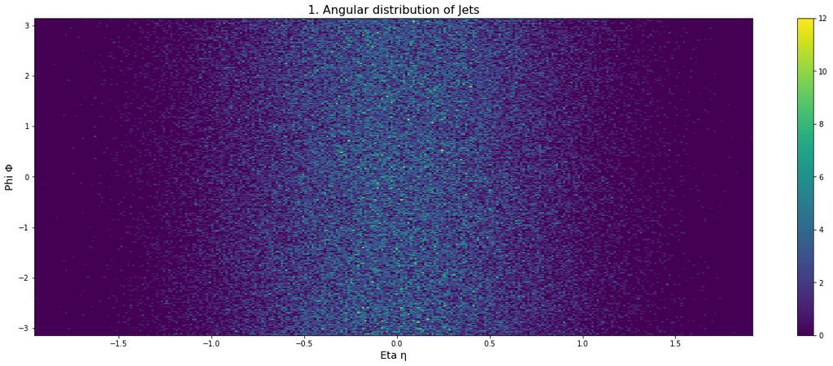

```python
fig,ax = plt.subplots(1,1)
plt.hist2d(higgsDF["eta"],higgsDF["phi"],300)
plt.colorbar()
plt.title("1. Angular distribution of Jets",fontsize=16)
plt.xlabel("Eta η",fontsize=14)
plt.ylabel("Phi Φ",fontsize=14)
plt.show()
```

Here I plotted out the distribution of jets based on their trajectory, the more yellow a bin is in this 2D histogram, the more jets there are in that bin. As you can see from the shape of the plot, the jet distribution is effectively uniform across all longitudinal angles Φ, but narrow about the beam axis when it comes to the polar pseudorapidity η.

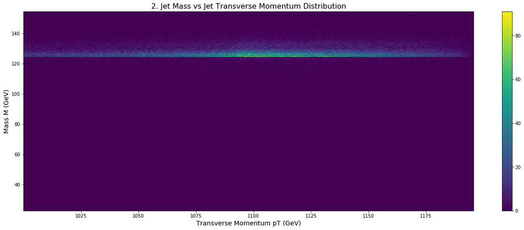

```python
fig,ax = plt.subplots(1,1)
plt.hist2d(higgsDF["pt"],higgsDF["mass"],300)
plt.colorbar()
plt.title("2. Jet Mass vs Jet Transverse Momentum Distribution",fontsize=16)
plt.xlabel("Transverse Momentum pT (GeV)",fontsize=14)
plt.ylabel("Mass M (GeV)",fontsize=14)
plt.show()
```

In this plot of M vs p<sub>T</sub>, it's immediately noticeable that the jets in this p<sub>T</sub> domain tend to have jet masses strictly at or above 125 GeV, which is pretty much the rest mass of the Higgs boson 125.18 ± 0.16 GeV. Since these jets are only a result of Higgs boson decays, I first assumed that the plot should strictly be a straight line at 125 GeV. In reality, this is the net mass of the jet, as taken from the sum of the energies and momenta of each particle in it. If the particles are spread out uniformally in a cone, then the longitudinal components of their momenta cancel out, effectively increasing the jet's mass. Therefore a jet with the same net p<sub>T</sub> could have a different p<sub>L</sub> along the beam axis, resulting in a different net energy but a Higgs boson-like jet, which would end up with a different jet mass in the end.

One thing worth mentioning is that around p<sub>T</sub> = 1100 GeV you find the most dense region of Higgs boson jets. I would predict that the reason why the jet mass has higher potential values at this p<sub>T</sub> is because the probability distribution function (pdf) of jet mass for a single jet is likely constant regardless of p<sub>T</sub>, but the number of Higgs boson jets does depend on p<sub>T</sub> and peaks at around p<sub>T</sub> = 1100 GeV. As a result, the overall pdf of jet mass over 100k jets will be the single jet mass pdf multiplied by the density of jets at the p<sub>T</sub> of interest. Next I'll graph a 1D Histogram of p<sub>T</sub>.

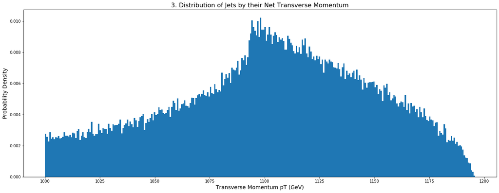

```python
fig,ax = plt.subplots(1,1)
plt.hist(higgsDF["pt"],300,density=True)
plt.title("3. Distribution of Jets by their Net Transverse Momentum",fontsize=16)
plt.xlabel("Transverse Momentum pT (GeV)",fontsize=14)
plt.ylabel("Probability Density",fontsize=14)
plt.show()
```

The pdf of jets vs their p<sub>T</sub> is peaked at around p<sub>T</sub> = 1100 GeV as expected by the jet mass plot (2). But what's intriguing here is the asymmetric shape this histogram takes, since the overall curve left of the peak is concave upwards, while the curve on the right is concave downwards and covers more probability. Looking back at the jet mass graph, you can actually visibly see this, which leads me to believe my prior reasoning that the jet mass pdf for a single jet is constant regardless of p<sub>T</sub>. Moreover, I believe that every plot with p<sub>T</sub> on the x-axis will lead to more dense results on the right side than the left.

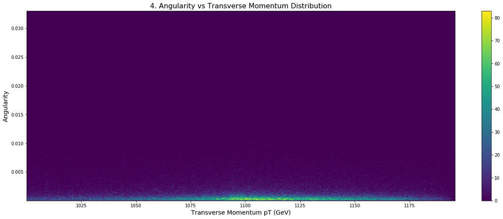

```python
fig,ax = plt.subplots(1,1)
plt.hist2d(higgsDF["pt"],higgsDF["angularity"],300)
plt.colorbar()
plt.title("4. Angularity vs Transverse Momentum Distribution",fontsize=16)
plt.xlabel("Transverse Momentum pT (GeV)",fontsize=14)
plt.ylabel("Angularity",fontsize=14)
plt.show()
```

This plot of angularity vs p<sub>T</sub> has a similar shape to the jet mass plot (2). Since higher angularities indicate the jet's particles being closer to the edges of the jet cone, more momentum cancellation occurs, leading to a higher overall jet mass. Because of that, I'd say that the jet mass plot (2) is dependent on this angularity plot.

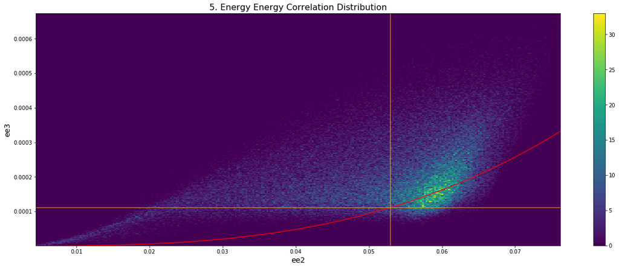

```
D2 of red cubic = 0.7505394050315742
```

```python
fig,ax = plt.subplots(1,1)
ind = 1005
x = np.linspace(min(higgsDF["ee2"]),max(higgsDF["ee2"]),1000)
y = higgsDF["d2"][ind] * np.power(x,3)

plt.hist2d(higgsDF["ee2"],higgsDF["ee3"],300)
plt.plot(x,y,color='Red',alpha=0.9)
plt.axvline(x=higgsDF["ee2"][ind],color='Orange',alpha=0.7)
plt.axhline(y=higgsDF["ee3"][ind],color='Orange',alpha=0.7)
plt.colorbar()
plt.title("5. Energy Energy Correlation Distribution",fontsize=16)
plt.xlabel("ee2",fontsize=14)
plt.ylabel("ee3",fontsize=14)
plt.show()

print("D2 of red cubic = " + str(higgsDF["d2"][ind]))
```

Note that I chose the red cubic to overlap the densest region of these jets, so for future reference, a good amount of jets have a D<sub>2</sub> of around 0.75.

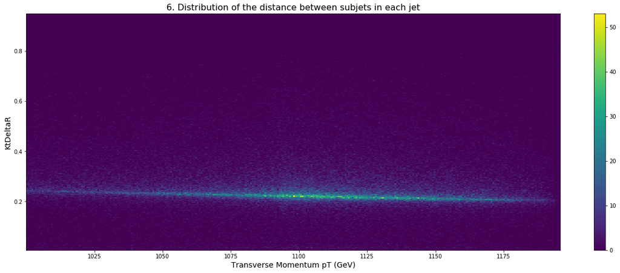

```python
fig,ax = plt.subplots(1,1)
plt.hist2d(higgsDF["pt"],higgsDF["KtDeltaR"],300)
plt.colorbar()
plt.title("6. Distribution of the distance between subjets in each jet",fontsize=16)
plt.xlabel("Transverse Momentum pT (GeV)",fontsize=14)
plt.ylabel("KtDeltaR",fontsize=14)
plt.show()
```

Here we can visibly see a slope to this distribution, which indicates that the distance between two subjets in a single Higgs boson jet k<sub>t</sub>ΔR is dependent on p<sub>T</sub>. The more transverse momentum the Higgs boson has, the closer its subjets will be.

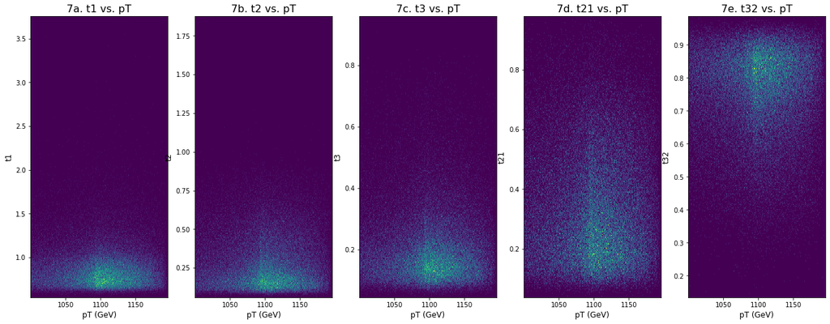

```python
fig,ax = plt.subplots(1,5)
nsub = ["1","2","3","21","32"]
lab = ["a","b","c","d","e"]

for i in range(0,5):
    plt.subplot(1,5,i+1)
    plt.hist2d(higgsDF["pt"],higgsDF["t" + nsub[i]],300)
    plt.title("7" + lab[i] + ". t" + nsub[i] + " vs. pT",fontsize=16)
    plt.xlabel("pT (GeV)",fontsize=12)
    plt.ylabel("t" + nsub[i],fontsize=12)

plt.show()
```

My overall interpretation of these N-subjettiness plots is that the Higgs boson primarily decays into jets with 2 subjets. My reasoning starts with posing that if you have a jet consisting of 2 subjets, then adding a third subjet axis would only make a small difference between τ<sub>2</sub> and τ<sub>3</sub>. However, if there were actually three subjets, then going from τ<sub>2</sub> to τ<sub>3</sub> would be significant, since if you only have 2 subjet axes in that case, you end up with many particles with huge distances coming from the third subjet to one of your two selected axes, whereas the third subjet would clear that distance quickly. Based on this reasoning, I think you should be able to detect the true number of subjets by examining the ratio τ<sub>N,N-1</sub>, the closer the ratio is to 1, the less significant the Nth subjet is in reducing the N-subjettiness. And upon looking at these plots, you can instantly notice how for the majority of jets in plot 7d, adding the 2nd subjet axis reduced the N-subjettiness significantly. In plot 7e, adding the 3rd subjet axis didn't change the majority of the jets' N-subjettiness by much. I would then infer from this that the majority of Higgs boson jets consist of only 2 subjets, which would seem to agree with the D<sub>2</sub> argument from plot 5.

## QCD background Data

Like I did for the Higgs boson data set, I'll be making similar plots for the QCD background data set in this section. I'll comment on any significant differences I see between the QCD plots and the Higgs boson plots.

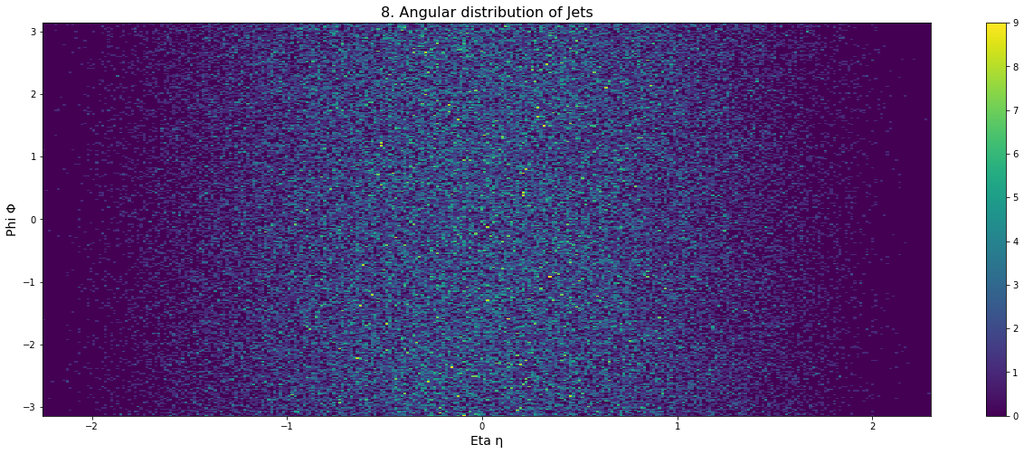

```python
fig,ax = plt.subplots(1,1)
plt.hist2d(qcdDF["eta"],qcdDF["phi"],300)
plt.colorbar()
plt.title("8. Angular distribution of Jets",fontsize=16)
plt.xlabel("Eta η",fontsize=14)
plt.ylabel("Phi Φ",fontsize=14)
plt.show()
```

Compared to plot 1, this distribution is slightly wider. The QCD background jets effectively contain the Higgs jets in terms of trajectories.

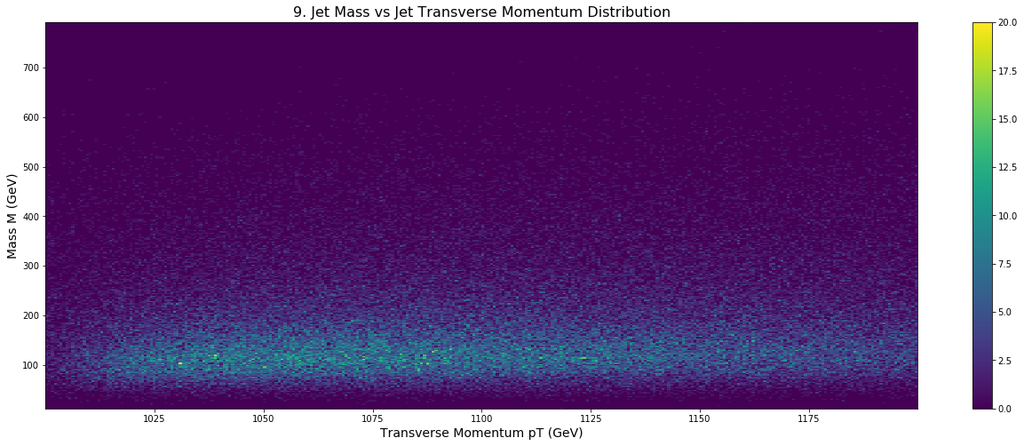

```python
fig,ax = plt.subplots(1,1)
plt.hist2d(qcdDF["pt"],qcdDF["mass"],300)
plt.colorbar()
plt.title("9. Jet Mass vs Jet Transverse Momentum Distribution",fontsize=16)
plt.xlabel("Transverse Momentum pT (GeV)",fontsize=14)
plt.ylabel("Mass M (GeV)",fontsize=14)
plt.show()
```

This plot plateaus earlier than M = 125 GeV in this case, and stretches out into the 200's and 300's of GeV, indicating that as you would expect, there're far more types of jets in the same p<sub>T</sub> range as the Higgs boson jets than just the Higgs bosons.

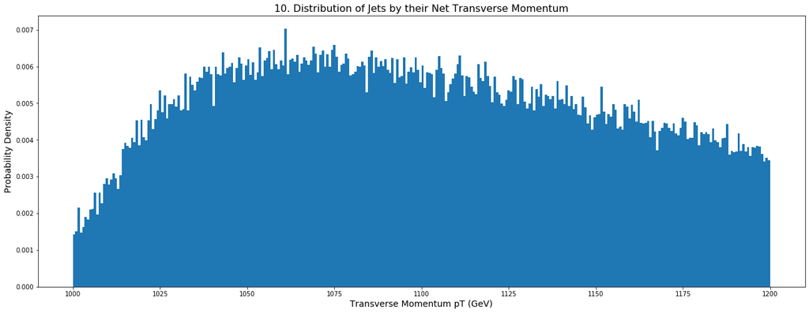

```python
fig,ax = plt.subplots(1,1)
plt.hist(qcdDF["pt"],300,density=True)
plt.title("10. Distribution of Jets by their Net Transverse Momentum",fontsize=16)
plt.xlabel("Transverse Momentum pT (GeV)",fontsize=14)
plt.ylabel("Probability Density",fontsize=14)
plt.show()
```

While this plot is also asymmetric, it's worth noting that the overall curve this histogram takes appears concave downwards. It also seems to peak at an earlier p<sub>T</sub> than 1100 GeV.

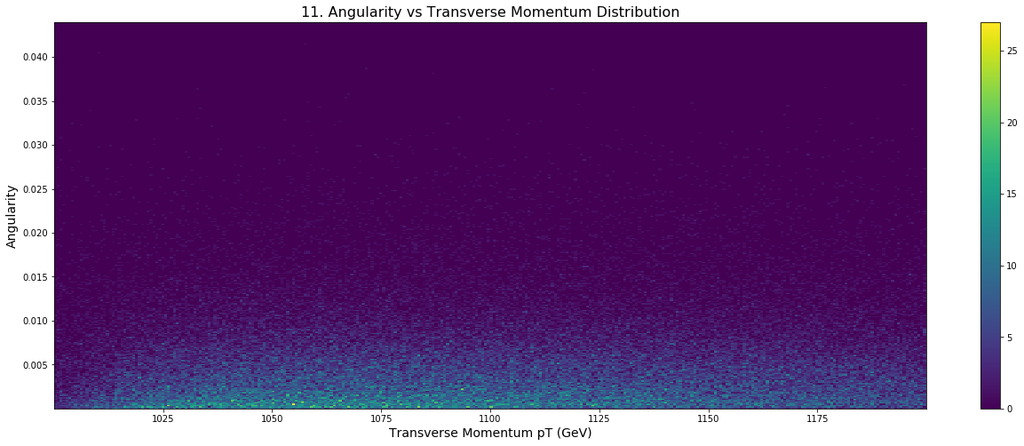

```python
fig,ax = plt.subplots(1,1)
plt.hist2d(qcdDF["pt"],qcdDF["angularity"],300)
plt.colorbar()
plt.title("11. Angularity vs Transverse Momentum Distribution",fontsize=16)
plt.xlabel("Transverse Momentum pT (GeV)",fontsize=14)
plt.ylabel("Angularity",fontsize=14)
plt.show()
```

Overall wider angularity distribution than plot 4.

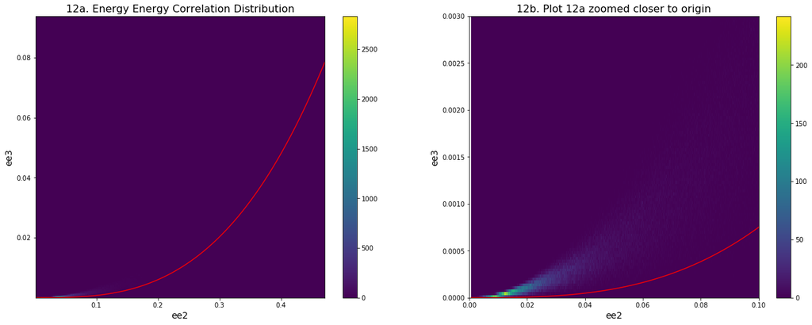

```python
fig,ax = plt.subplots(1,2)
x = np.linspace(min(qcdDF["ee2"]),max(qcdDF["ee2"]),1000)
y = 0.75 * np.power(x,3)

plt.subplot(1,2,1)
plt.hist2d(qcdDF["ee2"],qcdDF["ee3"],300)
plt.plot(x,y,color='Red',alpha=0.9)
plt.colorbar()
plt.title("12a. Energy Energy Correlation Distribution",fontsize=16)
plt.xlabel("ee2",fontsize=14)
plt.ylabel("ee3",fontsize=14)

plt.subplot(1,2,2)
plt.hist2d(qcdDF["ee2"],qcdDF["ee3"],3000)
plt.plot(x,y,color='Red',alpha=0.9)
plt.colorbar()
plt.title("12b. Plot 12a zoomed closer to origin",fontsize=16)
plt.xlabel("ee2",fontsize=14)
plt.ylabel("ee3",fontsize=14)
plt.xlim([0,0.1])
plt.ylim([0,0.003])
plt.show()
```

One thing worth noting is that I had to immensely zoom in on the 2D histogram from plot 12a (unscaled) to get a more visible plot 12b.

Finally, here's a very significant difference between the Higgs boson data and the QCD data. While you can see from plot 12b that unlike plot 5, the jets tend to naturally follow a cubic spread in the ee2-ee3 phase space, almost the entirety of jets in plot 12 end up above the red cubic, which represents the focal point of most of the Higgs boson jets' D<sub>2</sub> values from plot 5. In other words, there will be a large chunk of D<sub>2</sub> values from Higgs boson jets that are significantly smaller than the D<sub>2</sub> trend cubics for the QCD background jets. This could potentially be used to try to identify high-Sigma Higgs boson discoveries.

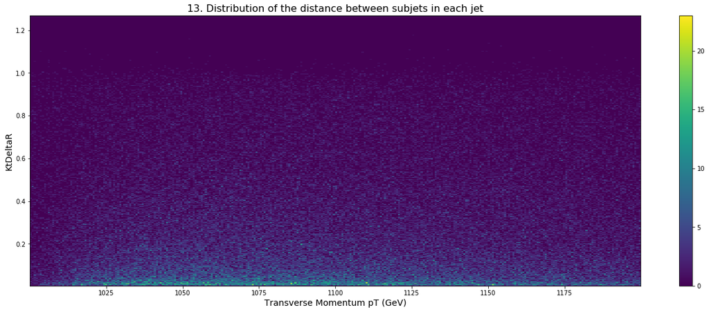

```python
fig,ax = plt.subplots(1,1)
plt.hist2d(qcdDF["pt"],qcdDF["KtDeltaR"],300)
plt.colorbar()
plt.title("13. Distribution of the distance between subjets in each jet",fontsize=16)
plt.xlabel("Transverse Momentum pT (GeV)",fontsize=14)
plt.ylabel("KtDeltaR",fontsize=14)
plt.show()
```

Immediately you can notice how dispersed the distance between subjets is, I would imagine that since the densest regions are at a near-zero k<sub>t</sub>ΔR, many of the QCD jets might only be 1-pronged. But there's also a wide variety of k<sub>t</sub>ΔR distances, which like plot 9, shows that there're many types of particle jets in the QCD background, as opposed to the clean line seen in plot 6.

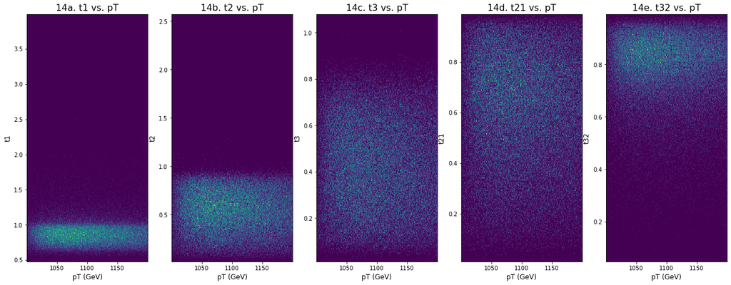

```python
fig,ax = plt.subplots(1,5)
nsub = ["1","2","3","21","32"]
lab = ["a","b","c","d","e"]

for i in range(0,5):
    plt.subplot(1,5,i+1)
    plt.hist2d(qcdDF["pt"],qcdDF["t" + nsub[i]],300)
    plt.title("14" + lab[i] + ". t" + nsub[i] + " vs. pT",fontsize=16)
    plt.xlabel("pT (GeV)",fontsize=12)
    plt.ylabel("t" + nsub[i],fontsize=12)

plt.show()
```

When reading these plots, just keep in mind where τ<sub>N</sub> = 1 is, since otherwise plot 14a looks half as tall as plot 14b.

Reading these plots and using a reasoning similar to what I did in plot 7, I would say that there's a significantly larger amount of 1-pronged jets in the QCD background than in the Higgs boson's case. Plot 14d especially shows this, as more than half of the jets have a τ<sub>21</sub> greater than 0.5, which is a far less significant difference in adding the 2nd subjet than plot 7d showed. But there's still a fair amount of jets with a τ<sub>21</sub> lesser than 0.5, unlike plot 14e which tends to agree with plot 7e, in that most of the time adding the 3rd subjet hardly makes a difference. Overall, there's a fair amount of both 1-pronged and 2-pronged jets in the QCD data set.

## Conclusion

Upon analyzing and trying to understand this data, I'd say that the most promising variable to try to isolate Higgs bosons with is D<sub>2</sub>, as the plots had a striking difference in focal points. The Higgs bosons in the densest region of plot 5 should have the highest Sigma of discovery when compared to the QCD background in plot 12.

## References

Schwartz, M. D. (2017). *TASI Lectures on Collider Physics*. Harvard University, Dept. of Physics. ARXIV. Retrieved from https://arxiv.org/abs/1709.04533

The CMS Collaboration. (2008). *The CMS Experiment at the CERN LHC*. IOPScience, Journal of Instrumentation. Retrieved from https://iopscience.iop.org/article/10.1088/1748-0221/3/08/S08004

The Atlas Collaboration. (2019). *Identification of boosted Higgs bosons decaying into b-quark pairs with the ATLAS detector at 13 TeV*. ARXIV, Eur. Phys. J. C 79. Retrieved from https://arxiv.org/abs/1906.11005

The Atlas Collaboration. (2016). *Identification of boosted, hadronically decaying W bosons and comparisons with ATLAS data taken at 8 TeV*. Springer Link, Eur. Phys. J. C 76. Retrieved from https://link.springer.com/article/10.1140/epjc/s10052-016-3978-z

Almeida, L. G. et al. (2008). *Substructure of high-p_T Jets at the LHC*. ARXIV, Phys.Rev.D79:074017. Retrieved from https://arxiv.org/abs/0807.0234

Larkoski, A. J., Moult, I., Neill, D. (2014). *Power Counting to Better Jet Observables*. ARXIV. Retrieved from https://arxiv.org/abs/1409.6298

Larkoski, A. J., Salam, G. P., Thaler, J. (2013). *Energy Correlation Functions for Jet Substructure*. ARXIV. Retrieved from https://arxiv.org/abs/1305.0007